# ForageModv02 Supplementary Analysis

## Population maintenance?

First, we checked to see whether all model runs maintained a population across all 2000 ticks.

```r
all.exp = unique(data$exp)

end.tick = unique(data$`tick-limit`)
fd = data %>% filter(ticks == end.tick)
finished.exp = unique(fd$exp)

finished.data = data %>% filter(exp %in% finished.exp)
unfinished.data = data %>% filter(!(exp %in% finished.exp))
length(unique(unfinished.data$exp))
```

```
## [1] 665
```

Approximately 9% (665 runs) of our modeled scenarios resulted in population extinction. Here we show how failures counts break down by the different parameters:

```
## $`natural-ignition`
##
##    0 0.05
##  665    0
##
## $`cycle-duration`
##
## 100 250
## 327 338
##
## $`veg-cycle-start`
##
##   "productive" "unproductive"
##            266            399
##
## $`veg-distribution`
##
##    "random" "clustered"
##         330         335
##
## $`burnt-neighbor-limit`
##
##   1   4   8
## 225 217 223
##
## $`burn-cost`
##
##   0 100 200 300
##   0   4 182 479
##
## $`burn-veg-type-threshold`
##
##   4   7
## 328 337
##
## $`movement-model`
##
##   "Random Walk" "Directed Walk"
##             665               0
```

We filter out these unsuccessful runs to avoid issues in analyzing trends over the course of model run.

```r
data = data %>% filter(exp %in% finished.exp)
```

## Correlations of outputs over time

Next, we looked at the correlation between outputs across model runs.

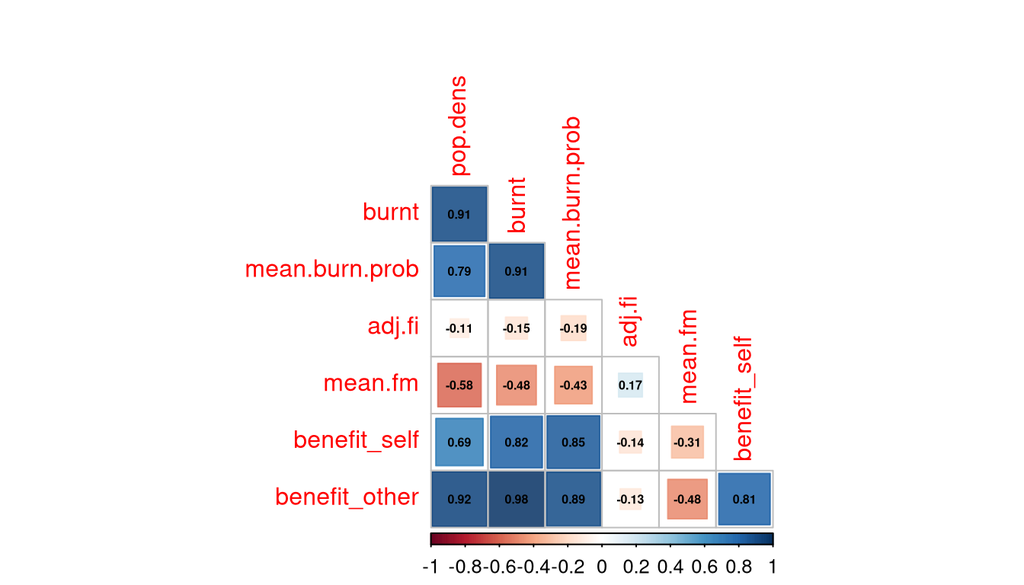

We can see that population density is strongly positively correlated with mean burning probability (*mean.burn.prob*). This indicates that large populations are more likely to burn the landscape. This contextualizes the positive correlation between population density and proportion of burnt landscape (*burnt*). We also see that population density is negatively correlated with forager movement (*mean.fm*), meaning foragers move less within large populations. Foragers also move less when they are burning the landscape more frequently.

We also investigated how these correlations change over time by looking at the correlations between outputs at 250 ticks, 1000 ticks, and 2000 ticks. For this, we also include spatial autocorrelation values of vegetation types and burning events, as well as a diversity metric of vegetation types.

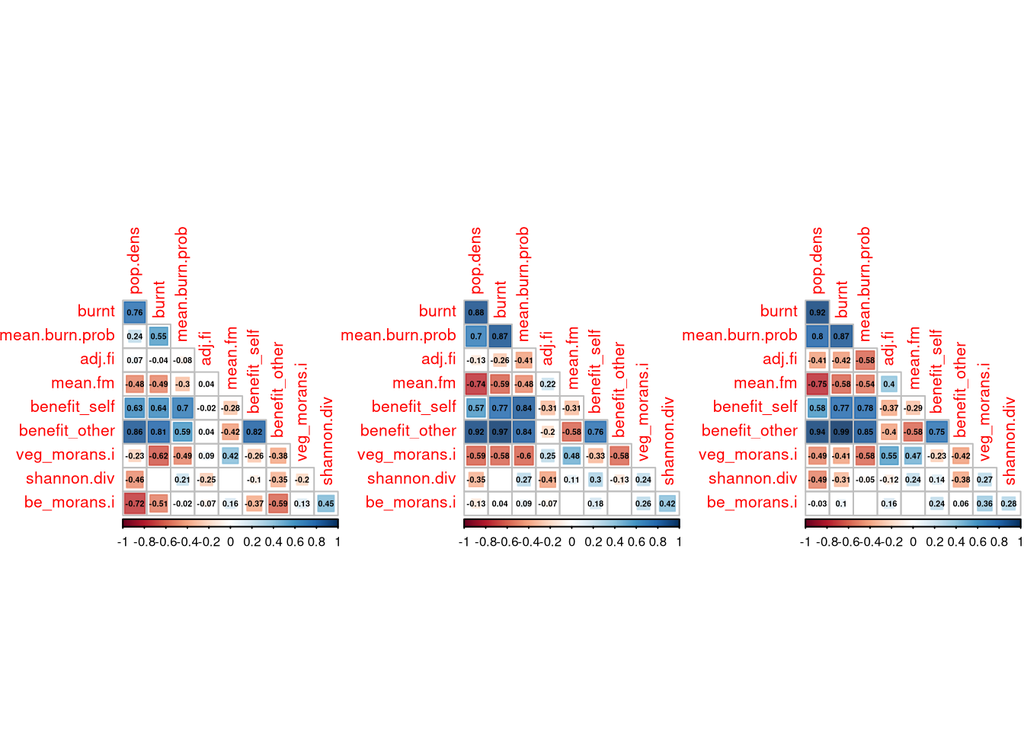

The direction of correlations between outputs remain relatively consistent over the course of model run, either becoming more positive or more negative.

These correlations over time begin to reveal some of the model behavior, demonstrating that spatial clustering of vegetation types decreases with increased burning, but is positively correlated with forager mobility and interactions.

## Population during model run

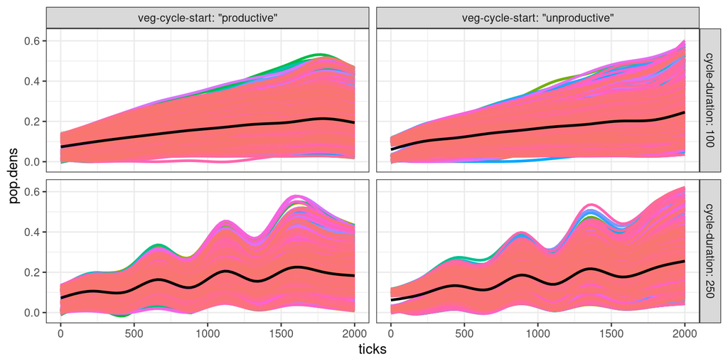

Population increases over time. There are fluctuations in population based on the climatic condition of the model, with steep drops in population when the landscape is unproductive. However, the overall trend of population increase is evident across all modeled scenarios.

## Forager probability of burning patches

We examined the effects of all model parameters on burning probability across model run using linear regressions. We model the effect of the different parameter settings on model behavior. We also model change over model run by including “ticks” as a independent variable. Finally, we investigate the interaction between time and model parameters.

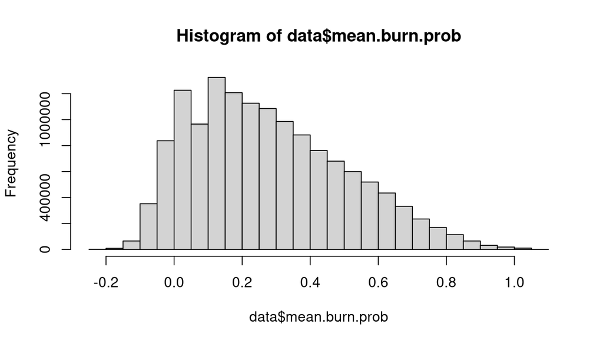

```r
hist(data$mean.burn.prob)
```

```r
mbp.fit1 = lm(mean.burn.prob ~ ticks + (.), data = data %>% dplyr::select_at(c("mean.burn.prob", "ticks", parameters)))
mbp.fit2 = lm(mean.burn.prob ~ ticks:(.), data = data %>% dplyr::select_at(c("mean.burn.prob", "ticks", parameters)))
mbp.fit3 = lm(mean.burn.prob ~ ticks*(.), data = data %>% dplyr::select_at(c("mean.burn.prob", "ticks", parameters)))

anova(mbp.fit1, mbp.fit2, mbp.fit3)
```

```
## Analysis of Variance Table
##
## Model 1: mean.burn.prob ~ ticks + (ticks + `natural-ignition` + `cycle-duration` +
##     `veg-cycle-start` + `veg-distribution` + `burnt-neighbor-limit` +
##     `burn-cost` + `burn-veg-type-threshold` + `movement-model`)
## Model 2: mean.burn.prob ~ ticks:(ticks + `natural-ignition` + `cycle-duration` +
##     `veg-cycle-start` + `veg-distribution` + `burnt-neighbor-limit` +
##     `burn-cost` + `burn-veg-type-threshold` + `movement-model`)
## Model 3: mean.burn.prob ~ ticks * (ticks + `natural-ignition` + `cycle-duration` +
##     `veg-cycle-start` + `veg-distribution` + `burnt-neighbor-limit` +
##     `burn-cost` + `burn-veg-type-threshold` + `movement-model`)
##     Res.Df    RSS Df Sum of Sq     F    Pr(>F)
## 1 14037002 123062
## 2 14037002  38827  0     84235
## 3 14036991  37355 11      1472 50301 < 2.2e-16 ***
## ---
## Signif. codes:  0 '***' 0.001 '**' 0.01 '*' 0.05 '.' 0.1 ' ' 1
```

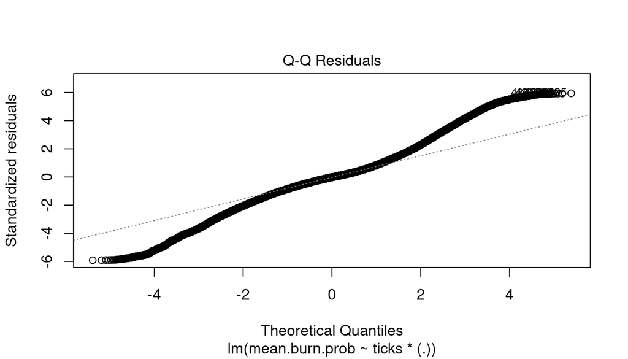

```r
plot(mbp.fit3, which = 2)
```

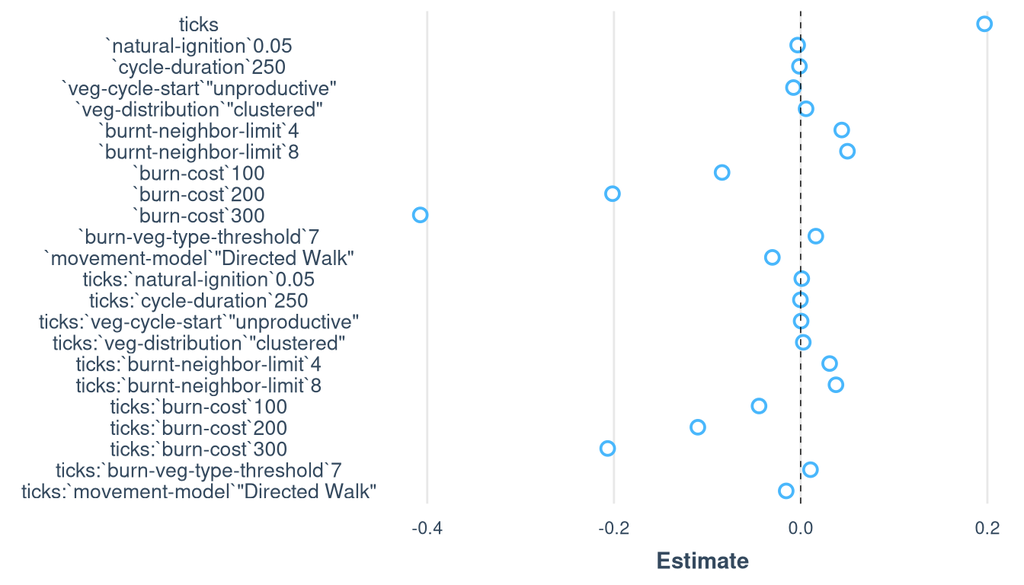

```r
plot_summs(mbp.fit3, scale = T)
```

Every parameter significantly affects burning probability on average across model run (independent variables) as well as how burning probability changes during model run (interaction variables). The scaled regression variables shown above also demonstrate that *burn-cost* has the strongest effect on the evolution of burning probability across model run.

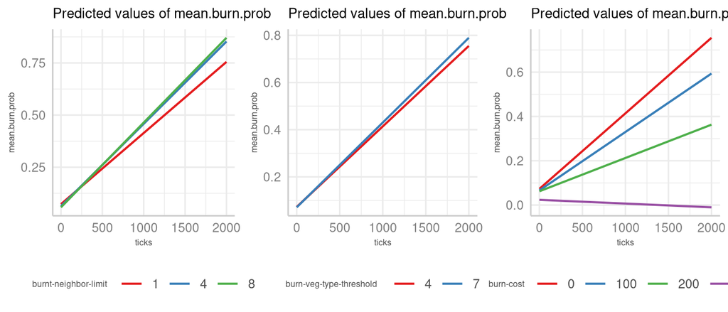

This model behavior is confirmed by looking at the effects of model parameters on slope of the linear relationship between ticks and burning probability.

```r
bp.rates = data.frame(
  exp = character(0),
  slope = numeric(0)
)
experiments = unique(data$exp)
for(x in experiments) {
  lmdata = data %>% filter(exp == x)
  fit = lm(mean.burn.prob ~ ticks, data = lmdata)
  bp.rates[nrow(bp.rates) + 1, ] <- c(x, summary(fit)$coefficients[2,1])
}
bp.rates = bp.rates %>% left_join(data %>% select_at(c("exp", parameters)), by = "exp", multiple = "first")
bp.rates$slope = as.numeric(bp.rates$slope)

bp.rates[,parameters] = lapply(bp.rates[,parameters], as.factor)
bp.rates$`veg-distribution` = factor(bp.rates$`veg-distribution`, levels = c("\"random\"", "\"clustered\""))
bp.rates$`movement-model` = factor(bp.rates$`movement-model`, levels = c("\"Random Walk\"", "\"Directed Walk\""))

rate.fit1= lm(slope ~ ., data = bp.rates %>% select_at(c("slope", parameters)))
rate.fit2 = lm(slope ~ .:., data = bp.rates %>% select_at(c("slope", parameters)))
anova(rate.fit1, rate.fit2)
```

```
## Analysis of Variance Table
##
## Model 1: slope ~ `natural-ignition` + `cycle-duration` + `veg-cycle-start` +
##     `veg-distribution` + `burnt-neighbor-limit` + `burn-cost` +
##     `burn-veg-type-threshold` + `movement-model`
## Model 2: slope ~ (`natural-ignition` + `cycle-duration` + `veg-cycle-start` +
##     `veg-distribution` + `burnt-neighbor-limit` + `burn-cost` +
##     `burn-veg-type-threshold` + `movement-model`):(`natural-ignition` +
##     `cycle-duration` + `veg-cycle-start` + `veg-distribution` +
##     `burnt-neighbor-limit` + `burn-cost` + `burn-veg-type-threshold` +
##     `movement-model`)
##   Res.Df        RSS Df  Sum of Sq      F    Pr(>F)
## 1   7003 1.2273e-05
## 2   6952 6.4721e-06 51 5.8008e-06 122.17 < 2.2e-16 ***
## ---
## Signif. codes:  0 '***' 0.001 '**' 0.01 '*' 0.05 '.' 0.1 ' ' 1
```

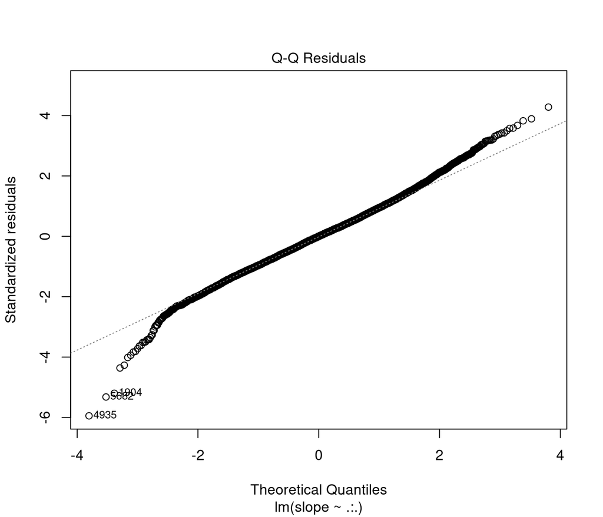

```r
plot(rate.fit2, which = 2)
```

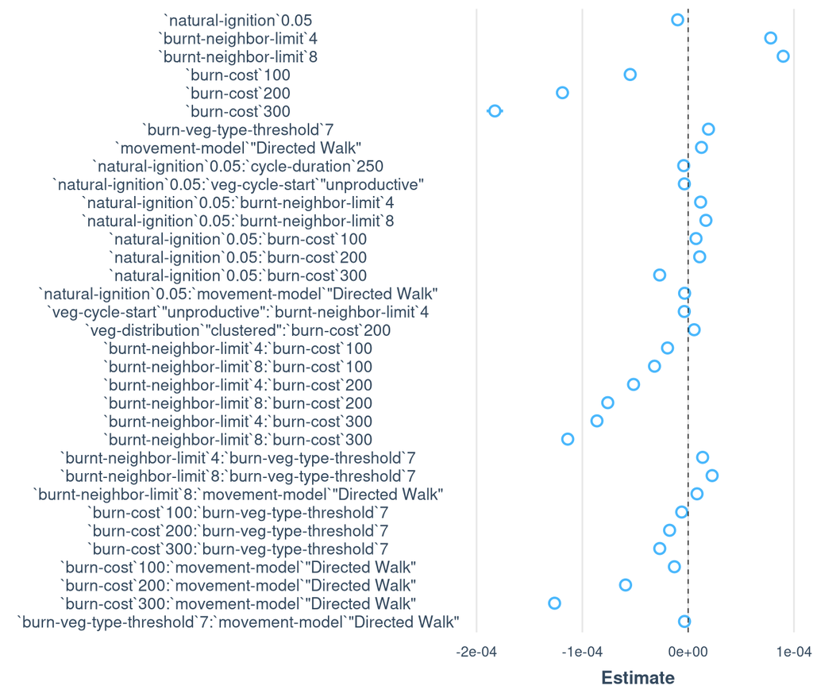

```r
rate.fit.df = rate.fit2 %>% broom::tidy() %>%
  mutate(p.signif = ifelse(p.value < 0.05, TRUE, FALSE)) %>%
  filter(p.signif == F)

plot_summs(rate.fit2, scale = T, omit.coefs = c("(Intercept)", rate.fit.df$term))
```

## Burnt landscape proportions

Initial correlations reveal that the proportion of burnt landscape is significantly highly correlated with population density and the average burning probability of agents.

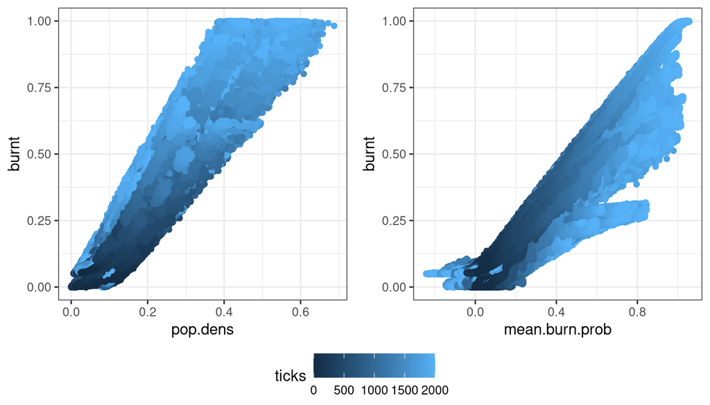

We used regressions on the proportions of burnt landscape to look at the effects of each parameter. We compared Beta regression and logistic regressions, which are often used for modeling proportion data, and linear regressions using AIC.

```r
beta.data = data %>% mutate(burnt = ifelse(burnt == 0, burnt + 0.00001, burnt)) %>% mutate(burnt = ifelse(burnt == 1, burnt - 0.00001, burnt))

beta.fit1 = betareg(burnt ~ ticks*(ticks + `natural-ignition` + `cycle-duration` +
                                     `veg-cycle-start` + `veg-distribution` + `burn-cost` + `burn-veg-type-threshold` +  `burnt-neighbor-limit` +
                                     `movement-model`), data = beta.data %>% select_at(c("ticks", "burnt", parameters)))

log.fit1 = glm(burnt ~ ticks*(ticks + `natural-ignition` + `cycle-duration` +
                                `veg-cycle-start` + `veg-distribution` + `burn-cost` + `burn-veg-type-threshold` +  `burnt-neighbor-limit` +
                                `movement-model`), data = data %>% select_at(c("ticks", "burnt", parameters)), family = binomial)

lin.fit1 = lm(burnt ~ ticks*(ticks + `natural-ignition` + `cycle-duration` +
                               `veg-cycle-start` + `veg-distribution` + `burn-cost` + `burn-veg-type-threshold` +  `burnt-neighbor-limit` +
                               `movement-model`), data = data %>% select_at(c("ticks", "burnt", parameters)))

AIC(beta.fit1)
```

```
## [1] -46076695
```

```r
AIC(log.fit1)
```

```
## [1] 6782305
```

```r
AIC(lin.fit1)
```

```
## [1] -39825278
```

```r
AIC(beta.fit1) < AIC(lin.fit1)
```

```
## [1] TRUE
```

Comparison of AIC shows that the Beta regression performs best.

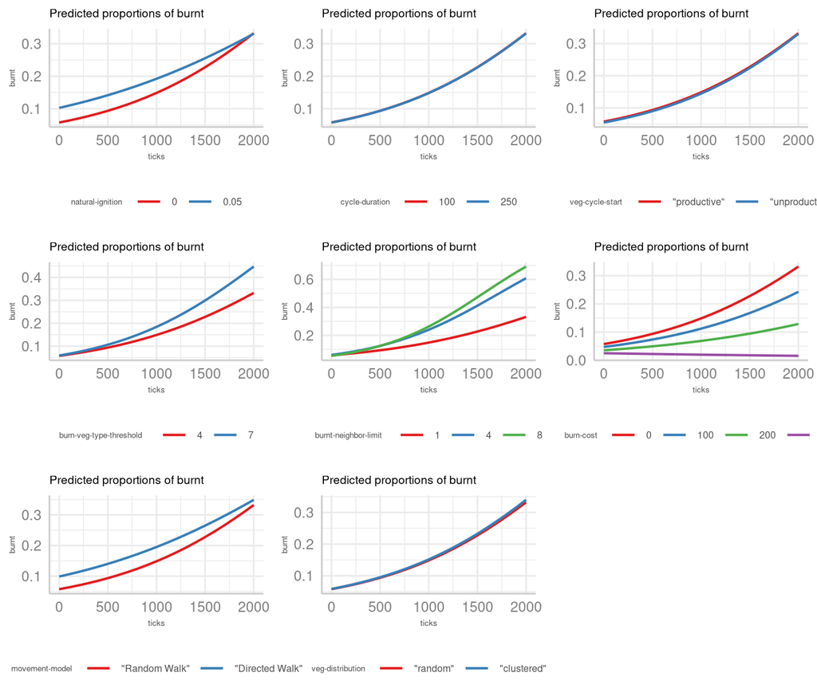

The predicted proportions of burnt landscape from the best fit Beta regression model show that increasing limits on location of burning or increasing cost to burning significantly affect the amount of burnt landscape. This matches the results above for the effect of these parameters on mean burning probability. This is also consistent with the high positive correlation between proportion of burnt landscape and burning probability through time.

## Spatial clustering of vegetation types

Spatial clustering (and its converse spatial heterogeneity) of vegetation types is assessed via Moran’s I values. We limit our analysis to those significant values of Moran’s I to assess the degree of clustering (positive values) or dispersion (negative values). We assessed the effects of the different parameters using linear regressions.

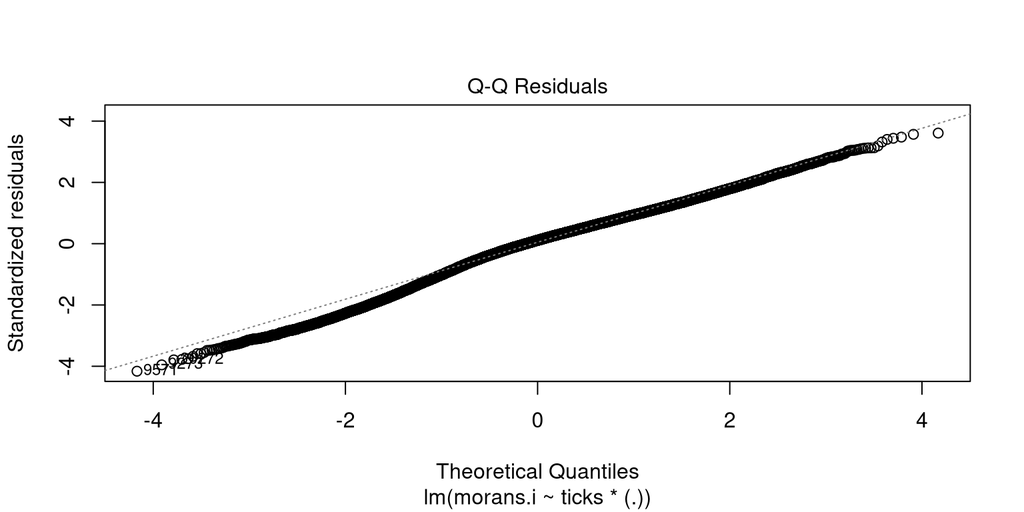

```r
veg.100.prod = readRDS("../results/outputs/veg_moransi_100-prod.rds")
veg.100.unprod = readRDS("../results/outputs/veg_moransi_100-unprod.rds")
veg.250.prod = readRDS("../results/outputs/veg_moransi_250-prod.rds")
veg.250.unprod = readRDS("../results/outputs/veg_moransi_250-unprod.rds")

veg.100.prod = veg.100.prod %>% filter(exp %in% finished.exp)
veg.100.unprod = veg.100.unprod %>% filter(exp %in% finished.exp)
veg.250.prod = veg.250.prod %>% filter(exp %in% finished.exp)
veg.250.unprod = veg.250.unprod %>% filter(exp %in% finished.exp)

veg.100.prod = veg.100.prod %>% filter(ticks != 1000) %>% filter(ticks != 2000)
veg.100.unprod = veg.100.unprod %>% filter(ticks != 1000) %>% filter(ticks != 2000)
veg.250.prod = veg.250.prod %>% filter(ticks != 1000) %>% filter(ticks != 2000)
veg.250.unprod = veg.250.unprod %>% filter(ticks != 1000) %>% filter(ticks != 2000)

parameters = c(
  "natural_ignition", # 0.00, 0.05
  "cycle_duration",  # 100, 250
  "veg_cycle_start", # productive, unproductive
  "veg_distribution", # random, clustered
  "burnt_neighbor_limit", # 1, 4, 8
  "burn_cost", # 0, 50
  "burn_veg_type_threshold", # 4, 7
  "movement_model" #Random, Directed
)

reg.params = parameters[c(1,4:8)]
veg.100.prod[,reg.params] = lapply(veg.100.prod[,reg.params], as.factor)
veg.100.unprod[,reg.params] = lapply(veg.100.unprod[,reg.params] , as.factor)
veg.250.prod[,reg.params] = lapply(veg.250.prod[,reg.params], as.factor)
veg.250.unprod[,reg.params] = lapply(veg.250.unprod[,reg.params] , as.factor)

veg.100.prod$veg_distribution = factor(veg.100.prod$veg_distribution, levels = c("\"random\"", "\"clustered\""))
veg.100.unprod$veg_distribution = factor(veg.100.unprod$veg_distribution, levels = c("\"random\"", "\"clustered\""))
veg.250.prod$veg_distribution = factor(veg.250.prod$veg_distribution, levels = c("\"random\"", "\"clustered\""))
veg.250.unprod$veg_distribution = factor(veg.250.unprod$veg_distribution, levels = c("\"random\"", "\"clustered\""))

veg.100.prod$movement_model = factor(veg.100.prod$movement_model, levels = c("\"Random Walk\"", "\"Directed Walk\""))
veg.100.unprod$movement_model = factor(veg.100.unprod$movement_model, levels = c("\"Random Walk\"", "\"Directed Walk\""))
veg.250.prod$movement_model = factor(veg.250.prod$movement_model, levels = c("\"Random Walk\"", "\"Directed Walk\""))
veg.250.unprod$movement_model = factor(veg.250.unprod$movement_model, levels = c("\"Random Walk\"", "\"Directed Walk\""))

# hist(veg.100.prod$morans.i)
# hist(veg.100.unprod$morans.i)
# hist(veg.250.prod$morans.i)
# hist(veg.250.unprod$morans.i)

veg.100.prod.fit1 = lm(morans.i ~ ticks*(.), data = veg.100.prod %>% filter(signif == T) %>% select_at(c("ticks", "morans.i", reg.params)))

veg.100.unprod.fit1 = lm(morans.i ~ ticks*(.), data = veg.100.unprod %>% filter(signif == T) %>% select_at(c("ticks", "morans.i", reg.params)))

veg.250.prod.fit1 = lm(morans.i ~ ticks*(.), data = veg.250.prod %>% filter(signif == T) %>% select_at(c("ticks", "morans.i", reg.params)))

veg.250.unprod.fit1 = lm(morans.i ~ ticks*(.), data = veg.250.unprod %>% filter(signif == T) %>% select_at(c("ticks", "morans.i", reg.params)))

plot(veg.100.prod.fit1, which = 2)
```

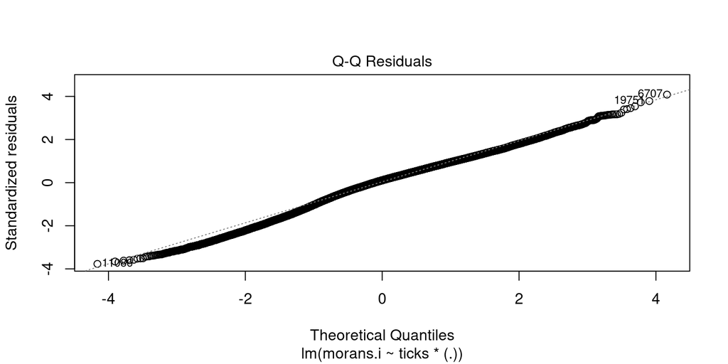

```r
plot(veg.100.unprod.fit1, which = 2)
```

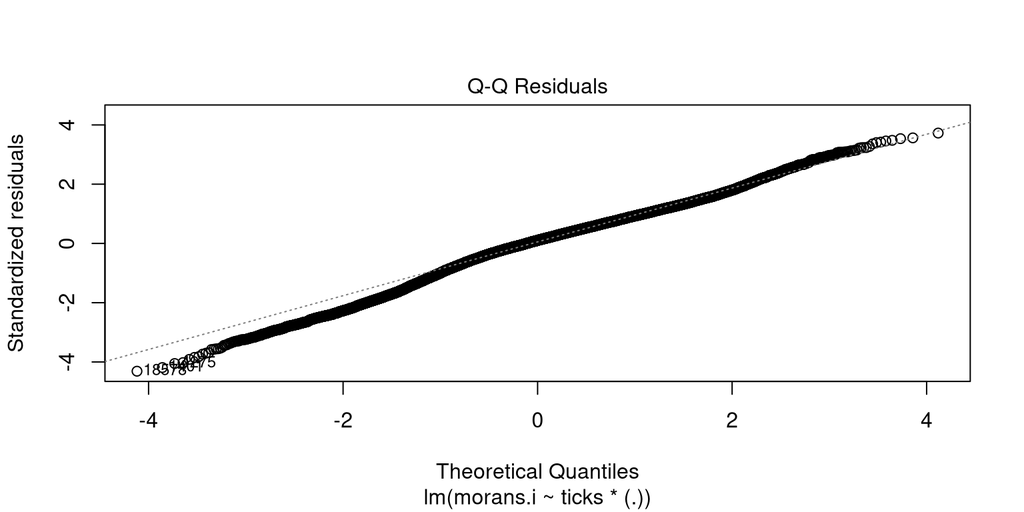

```r
plot(veg.250.prod.fit1, which = 2)
```

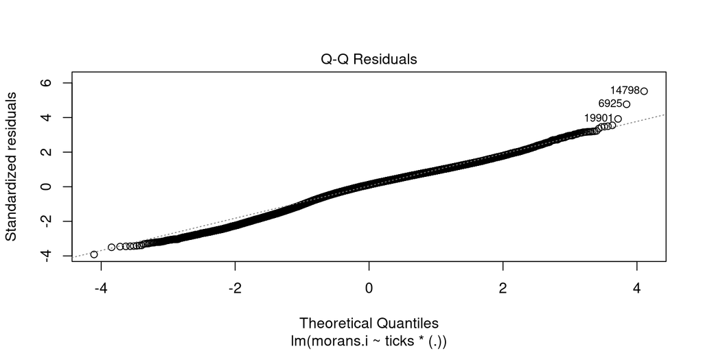

```r
plot(veg.250.unprod.fit1, which = 2)
```

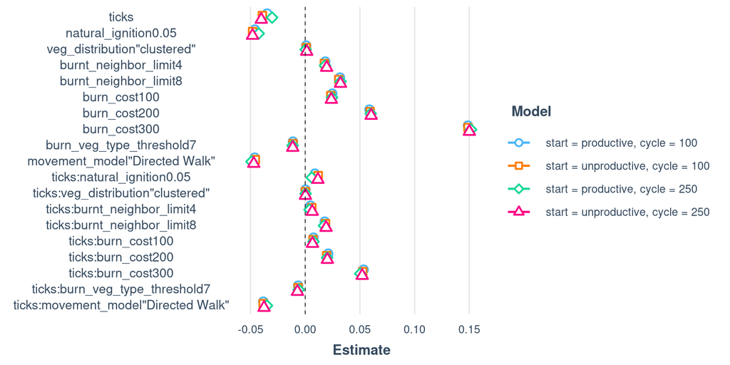

```r
plot_summs(veg.100.prod.fit1, veg.100.unprod.fit1,veg.250.prod.fit1, veg.250.unprod.fit1, model.names = c(
  "start = productive, cycle = 100",
  "start = unproductive, cycle = 100",
  "start = productive, cycle = 250",
  "start = unproductive, cycle = 250"
), scale = T)
```

Looking at the standardized regression coefficients, we can see that high/medium cost of burning behaviors and a directed walk movement model have the greatest impact on clustering of vegetation types. Interestingly, the underlying distribution of maximum potential vegetation types for patches has essentially no impact on spatial clustering of vegetation types relative to the other parameters.

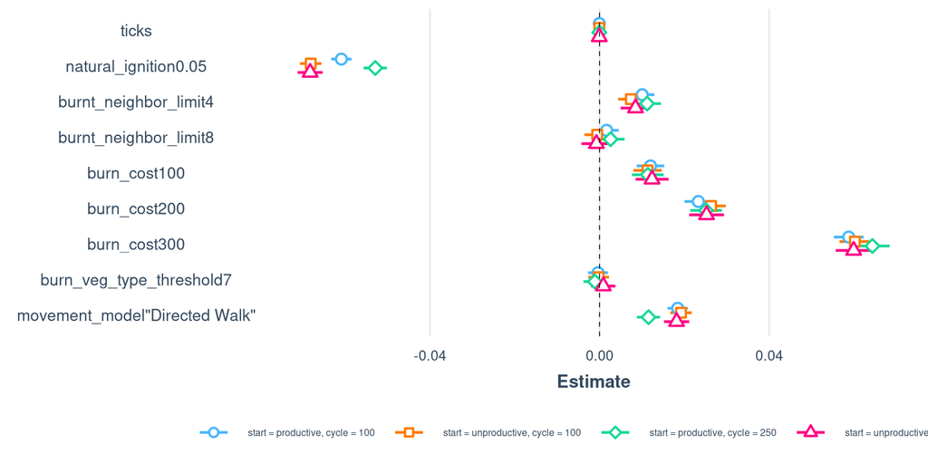

```r
plot_summs(veg.100.prod.fit1, veg.100.unprod.fit1,veg.250.prod.fit1, veg.250.unprod.fit1, model.names = c(
  "start = productive, cycle = 100",
  "start = unproductive, cycle = 100",
  "start = productive, cycle = 250",
  "start = unproductive, cycle = 250"
), coefs = c("ticks", "natural_ignition0.05", "veg_distribution\"random\"", "burnt_neighbor_limit4", "burnt_neighbor_limit8", "burn_cost100", "burn_cost200", "burn_cost300", "burn_veg_type_threshold7", "movement_model\"Directed Walk\"")) +
  theme(legend.position = "bottom", legend.title = element_blank(), legend.text = element_text(size = 6))
```

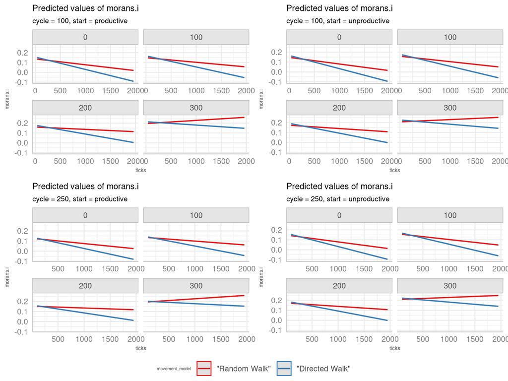

```r
ggarrange(
  ggeffects::ggpredict(veg.100.prod.fit1, terms = c("ticks", "movement_model", "burn_cost")) %>%
    plot(show_data = FALSE, show_ci = TRUE) +
    theme(legend.title = element_text(size = 5), title = element_text(size = 8), axis.title = element_text(size = 6)) +
    labs(subtitle = "cycle = 100, start = productive"),
  ggeffects::ggpredict(veg.100.unprod.fit1, terms = c("ticks", "movement_model", "burn_cost")) %>%
    plot(show_data = FALSE, show_ci = TRUE) +
    theme(legend.title = element_text(size = 6), title = element_text(size = 8), axis.title = element_text(size = 6)) +
    labs(subtitle = "cycle = 100, start = unproductive"),
  ggeffects::ggpredict(veg.250.prod.fit1, terms = c("ticks", "movement_model", "burn_cost")) %>%
    plot(show_data = FALSE, show_ci = TRUE) +
    theme(legend.title = element_text(size = 6), title = element_text(size = 8), axis.title = element_text(size = 6)) +
    labs(subtitle = "cycle = 250, start = productive"),
  ggeffects::ggpredict(veg.250.unprod.fit1, terms = c("ticks", "movement_model", "burn_cost")) %>%
    plot(show_data = FALSE, show_ci = TRUE) +
    theme(legend.title = element_text(size = 6), title = element_text(size = 8), axis.title = element_text(size = 6)) +
    labs(subtitle = "cycle = 250, start = unproductive"),
  common.legend = T, legend = "bottom", nrow = 2, ncol = 2)
```

## Vegetation diversity

Vegetation diversity was measured by Shannon’s Diversity Index. This metric considers the proportional abundances of vegetation types to indicate whether one type dominates or abundances are more evenly spread across all types. A SDI value of 0 indicates a lack of diversity with abundance being concentrated in a single species. Higher SDI values indicate more diversity of vegetation types.

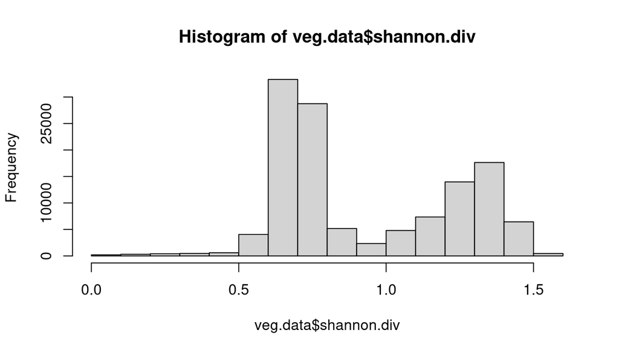

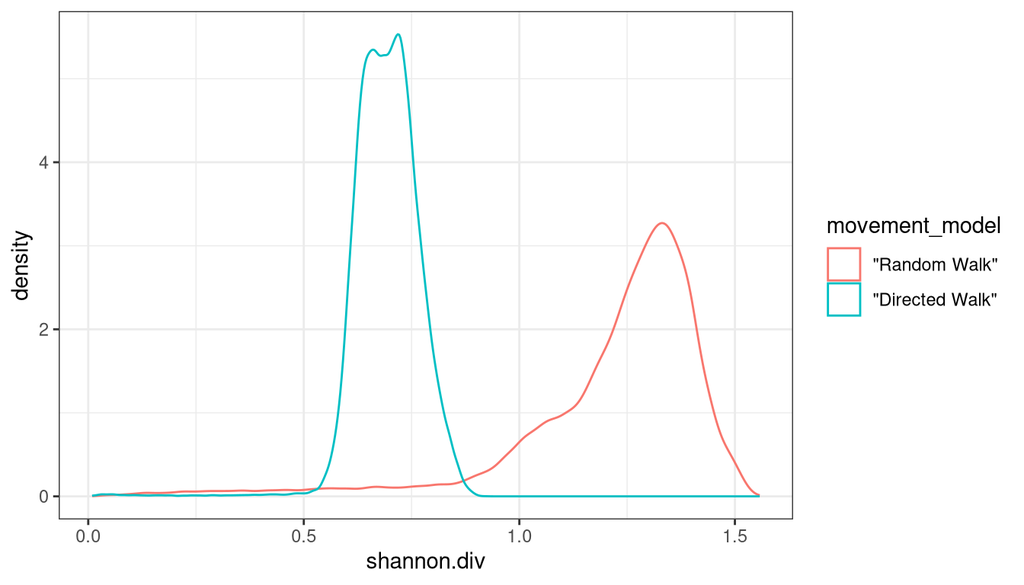

The distribution of this metric is bimodal across model runs. This bimodality is caused by the different movement models used: directed walks result in less diversity than random walks.

We fit a GAM to vegetation type diversity for model runs with random walks because it is a better fit than a linear model. We use GAM to investigate how the effects of the parameters change through time.

```r
veg.data.r = veg.data %>% filter(movement_model == "\"Random Walk\"")
reg.params = parameters = c(
  "natural_ignition", # 0.00, 0.05
  "cycle_duration",  # 100, 250
  "veg_cycle_start", # productive, unproductive
  "veg_distribution", # random, clustered
  "burnt_neighbor_limit", # 1, 4, 8
  "burn_cost", # 0, 50
  "burn_veg_type_threshold"
)
veg.data.r[,reg.params] = lapply(veg.data.r [,reg.params], as.factor)

rw.gam1 = gam(shannon.div ~
                s(ticks, by = natural_ignition) +
                s(ticks, by = veg_cycle_start) +
                s(ticks, by = veg_distribution) +
                s(ticks, by = burn_cost)  +
                s(ticks, by = burn_veg_type_threshold) +
                s(ticks, by = burnt_neighbor_limit) +
                s(ticks, by = cycle_duration), data = veg.data.r)

rw.gam2 = gam(shannon.div ~ natural_ignition + veg_cycle_start + veg_distribution + burn_cost + burn_veg_type_threshold + burnt_neighbor_limit + cycle_duration +
                s(ticks, by = natural_ignition) +
                s(ticks, by = veg_cycle_start) +
                s(ticks, by = veg_distribution) +
                s(ticks, by = burn_cost)  +
                s(ticks, by = burn_veg_type_threshold) +
                s(ticks, by = burnt_neighbor_limit) +
                s(ticks, by = cycle_duration), data = veg.data.r)

anova(rw.gam1, rw.gam2, test = "Chisq")
```

```
## Analysis of Deviance Table
##
## Model 1: shannon.div ~ s(ticks, by = natural_ignition) + s(ticks, by = veg_cycle_start) +
##     s(ticks, by = veg_distribution) + s(ticks, by = burn_cost) +
##     s(ticks, by = burn_veg_type_threshold) + s(ticks, by = burnt_neighbor_limit) +
##     s(ticks, by = cycle_duration)
## Model 2: shannon.div ~ natural_ignition + veg_cycle_start + veg_distribution +
##     burn_cost + burn_veg_type_threshold + burnt_neighbor_limit +
##     cycle_duration + s(ticks, by = natural_ignition) + s(ticks,
##     by = veg_cycle_start) + s(ticks, by = veg_distribution) +
##     s(ticks, by = burn_cost) + s(ticks, by = burn_veg_type_threshold) +
##     s(ticks, by = burnt_neighbor_limit) + s(ticks, by = cycle_duration)
##   Resid. Df Resid. Dev    Df Deviance  Pr(>Chi)
## 1     57097    1333.60
## 2     57085     929.93 12.02   403.66 < 2.2e-16 ***
## ---
## Signif. codes:  0 '***' 0.001 '**' 0.01 '*' 0.05 '.' 0.1 ' ' 1
```

```r
rw.fit1 = lm(shannon.div ~ ticks*(.), data = veg.data.r %>% select_at(c("ticks", "shannon.div", reg.params)))

AIC(rw.gam2)
```

```
## [1] -73064.42
```

```r
AIC(rw.fit1)
```

```
## [1] -41691
```

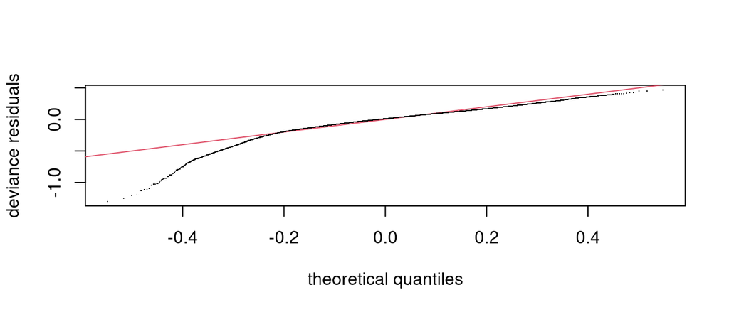

```r
qq.gam(rw.gam2)
```

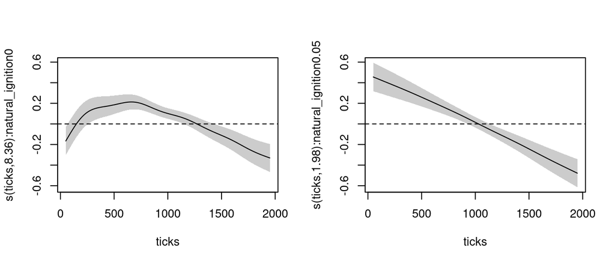

```r
par(mfrow=c(1,2), cex=0.8)
plot(rw.gam2, select=1, shade=T)
abline(h=0, lty = 2)
plot(rw.gam2, select=2, shade=T)
abline(h=0, lty = 2)
```

When there is natural ignition events in the model, we can see that vegetation diversity steadily decreases. Conversely, without natural ignition events, there is initially an increase in vegetation diversity and then a steady decreases. This is likely because diversity decreases as the proportion of burnt landscape steadily increases over model run. Having natural ignition events simply creates even more burnt landscape.

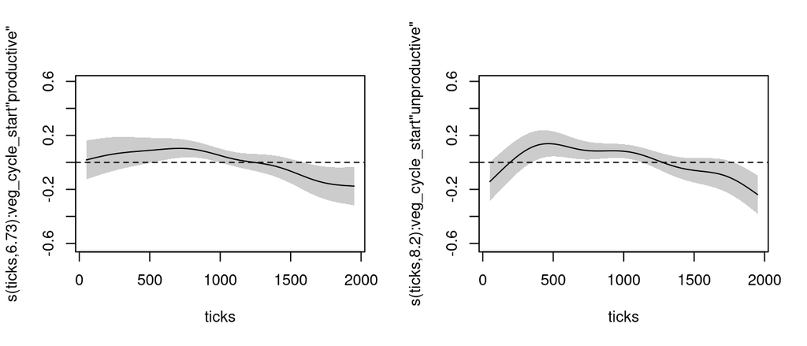

```r
par(mfrow=c(1,2), cex=0.8)
plot(rw.gam2, select=3, shade=T)
abline(h=0, lty = 2)
plot(rw.gam2, select=4, shade=T)
abline(h=0, lty = 2)
```

The starting environmental conditions do not appear to have a large effect on vegetation diversity.

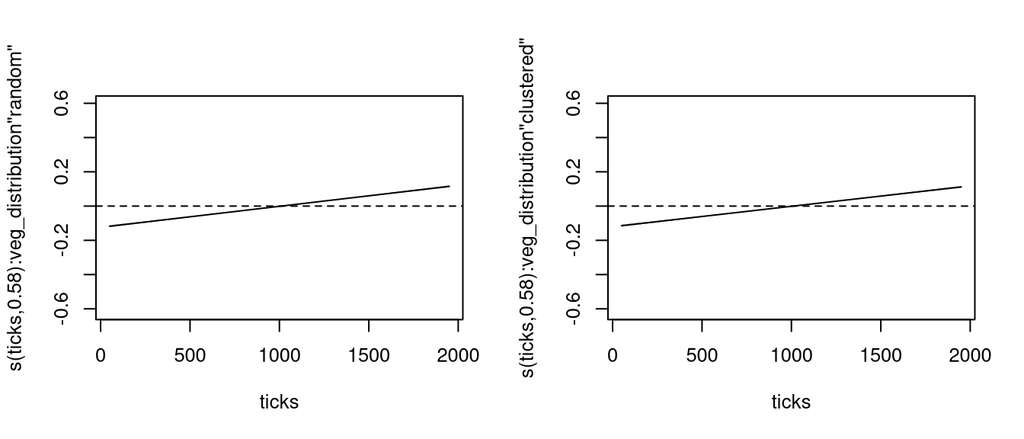

```r
par(mfrow=c(1,2), cex=0.8)
plot(rw.gam2, select=5, shade=T)
abline(h=0, lty = 2)
plot(rw.gam2, select=6, shade=T)
abline(h=0, lty = 2)
```

The underlying distribution of resource potential, or maximum vegetation type value, also do not have different effects on vegetation diversity - both distributions have slightly increasingly positive effects over the course of model run.

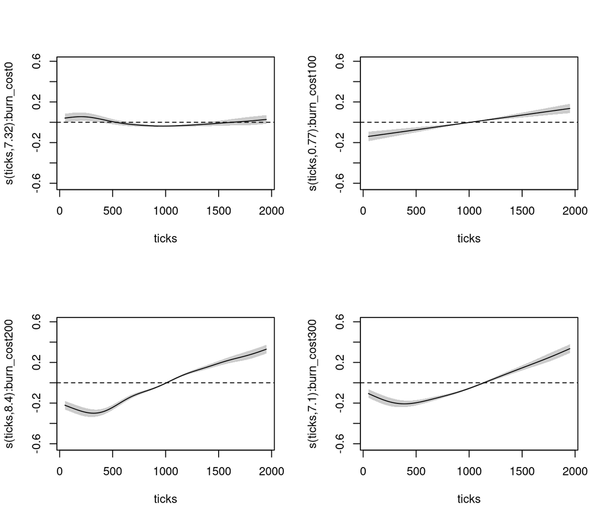

```r
par(mfrow=c(2,2), cex=0.8)
plot(rw.gam2, select=7, shade=T)
abline(h=0, lty = 2)
plot(rw.gam2, select=8, shade=T)
abline(h=0, lty = 2)
plot(rw.gam2, select=9, shade=T)
abline(h=0, lty = 2)
plot(rw.gam2, select=10, shade=T)
abline(h=0, lty = 2)
```

Having a cost associated with burning introduces a larger effect on vegetation diversity than no or low costs of burning. This is likely related to the fact that a burning cost reduces the amount of burning over the course of model run, allowing for a landscape that is not dominated by burnt patches.

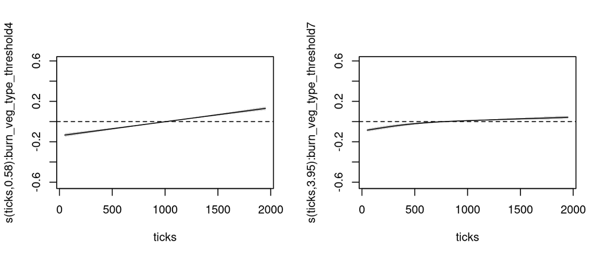

```r
par(mfrow=c(1,2), cex=0.8)
plot(rw.gam2, select=11, shade=T)
abline(h=0, lty = 2)
plot(rw.gam2, select=12, shade=T)
abline(h=0, lty = 2)
```

Similarly, stricter limits on what types of vegetation can be burned also allows for more vegetation diversity by the end of model run.

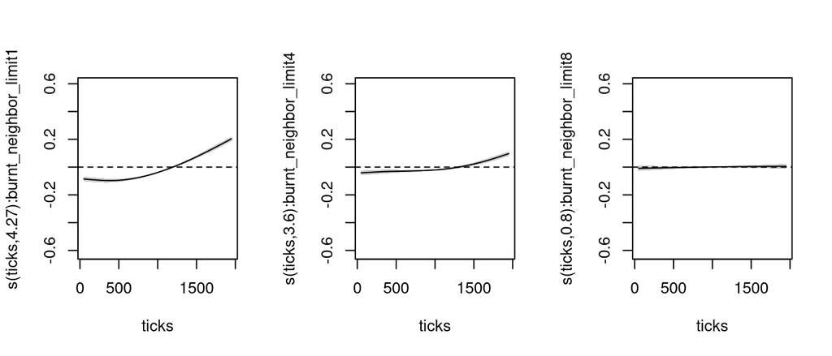

```r
par(mfrow=c(1,3), cex=0.8)
plot(rw.gam2, select=13, shade=T)
abline(h=0, lty = 2)
plot(rw.gam2, select=14, shade=T)
abline(h=0, lty = 2)
plot(rw.gam2, select=15, shade=T)
abline(h=0, lty = 2)
```

This same pattern is seen even more distinctly with the stricter burnt neighbor limits.

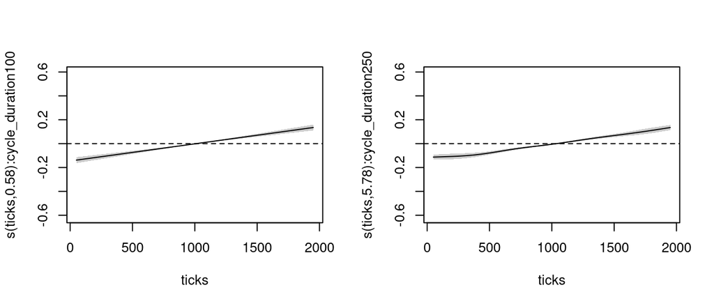

```r
par(mfrow=c(1,2), cex=0.8)
plot(rw.gam2, select=16, shade=T)
abline(h=0, lty = 2)
plot(rw.gam2, select=17, shade=T)
abline(h=0, lty = 2)
```

Both values of cycle duration have similar effects.

We fit a second GAM to vegetation type diversity for model runs with directed walks.

```r
veg.data.d = veg.data %>% filter(movement_model == "\"Directed Walk\"")
reg.params = parameters = c(
  "natural_ignition", # 0.00, 0.05
  "cycle_duration",  # 100, 250
  "veg_cycle_start", # productive, unproductive
  "veg_distribution", # random, clustered
  "burnt_neighbor_limit", # 1, 4, 8
  "burn_cost", # 0, 50
  "burn_veg_type_threshold"
)
veg.data.d[,reg.params] = lapply(veg.data.d[,reg.params], as.factor)

dw.gam1 = gam(shannon.div ~ s(ticks, by = natural_ignition) +
                s(ticks, by = veg_cycle_start) +
                s(ticks, by = veg_distribution) +
                s(ticks, by = burn_cost)  +
                s(ticks, by = burn_veg_type_threshold) +
                s(ticks, by = as.factor(burnt_neighbor_limit)) +
                s(ticks, by = cycle_duration), data = veg.data.d)

dw.gam2 = gam(shannon.div ~ natural_ignition + veg_cycle_start + veg_distribution + burn_cost + burn_veg_type_threshold + burnt_neighbor_limit + cycle_duration +
                s(ticks, by = natural_ignition) +
                s(ticks, by = veg_cycle_start) +
                s(ticks, by = veg_distribution) +
                s(ticks, by = burn_cost)  +
                s(ticks, by = burn_veg_type_threshold) +
                s(ticks, by = burnt_neighbor_limit) +
                s(ticks, by = cycle_duration), data = veg.data.d)

anova(dw.gam1, dw.gam2, test = "Chisq")
```

```
## Analysis of Deviance Table
##
## Model 1: shannon.div ~ s(ticks, by = natural_ignition) + s(ticks, by = veg_cycle_start) +
##     s(ticks, by = veg_distribution) + s(ticks, by = burn_cost) +
##     s(ticks, by = burn_veg_type_threshold) + s(ticks, by = as.factor(burnt_neighbor_limit)) +
##     s(ticks, by = cycle_duration)
## Model 2: shannon.div ~ natural_ignition + veg_cycle_start + veg_distribution +
##     burn_cost + burn_veg_type_threshold + burnt_neighbor_limit +
##     cycle_duration + s(ticks, by = natural_ignition) + s(ticks,
##     by = veg_cycle_start) + s(ticks, by = veg_distribution) +
##     s(ticks, by = burn_cost) + s(ticks, by = burn_veg_type_threshold) +
##     s(ticks, by = burnt_neighbor_limit) + s(ticks, by = cycle_duration)
##   Resid. Df Resid. Dev     Df Deviance  Pr(>Chi)
## 1     69064     288.23
## 2     69054     219.07 9.8066   69.166 < 2.2e-16 ***
## ---
## Signif. codes:  0 '***' 0.001 '**' 0.01 '*' 0.05 '.' 0.1 ' ' 1
```

```r
dw.fit1 = lm(shannon.div ~ ticks*(.), data = veg.data.d %>% select_at(c("ticks", "shannon.div", reg.params)))

AIC(dw.gam2)
```

```
## [1] -201456.2
```

```r
AIC(dw.fit1)
```

```
## [1] -185203.2
```

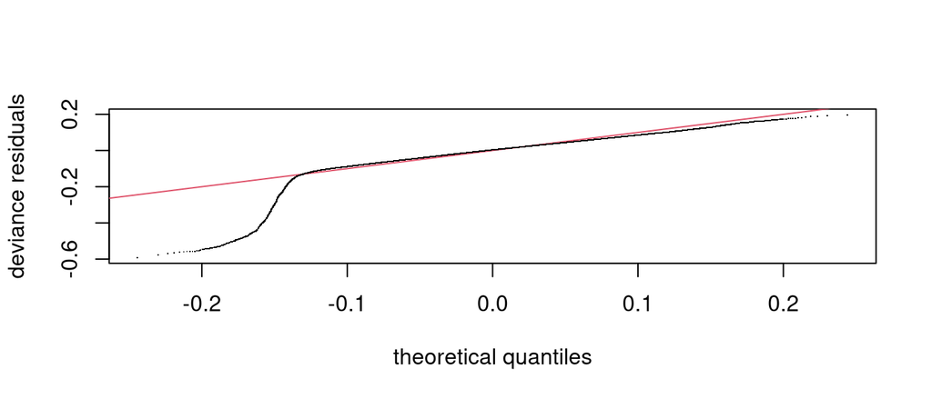

```r
qq.gam(dw.gam2)
```

Overall with directed walks, we get very similar parameter effects through time for most of the parameters. There are, however, key differences in the effects of burning costs and limits to where burning can occur.

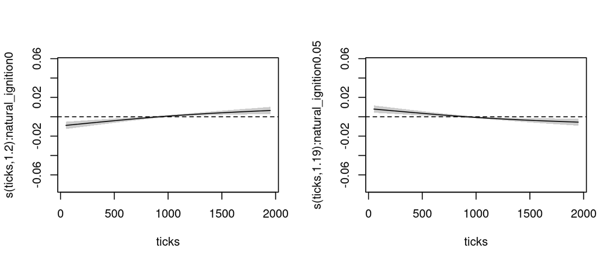

```r
par(mfrow=c(1,2), cex=0.8)
plot(dw.gam2, select=1, shade=T)
abline(h=0, lty = 2)
plot(dw.gam2, select=2, shade=T)
abline(h=0, lty = 2)
```

For directed walks, natural ignition does not have a very large effect on vegetation diversity.

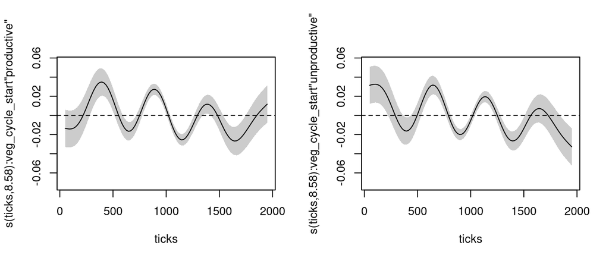

```r
par(mfrow=c(1,2), cex=0.8)
plot(dw.gam2, select=3, shade=T)
abline(h=0, lty = 2)
plot(dw.gam2, select=4, shade=T)
abline(h=0, lty = 2)
```

We again see similar effects of both starting vegetation conditions on vegetation diversity across model run.

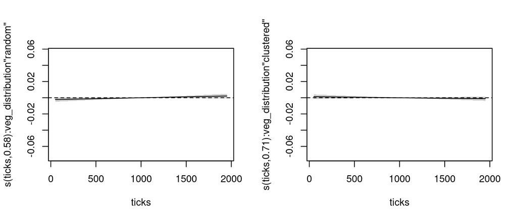

```r
par(mfrow=c(1,2), cex=0.8)
plot(dw.gam2, select=5, shade=T)
abline(h=0, lty = 2)
plot(dw.gam2, select=6, shade=T)
abline(h=0, lty = 2)
```

The underlying distribution of resource potential, or maximum vegetation type value, have essentially no effect on vegetation diversity with directed walks. This means that the human behavior is more important for structuring the environment with this movement model.